# MLR-Adelie-Penguin

# (3) Use the marginal distribution of $\hat{\beta}_3$ to perform a t–test for the hypothesis $H_0: \beta_3 = 0$ with a significance level $\alpha = 0.01$. Provide the value of the test statistic and the p-value.

```r
# Fit the multiple linear regression model
model <- lm(y ~ x1 + x2 + x3)

# Extract coefficients and standard errors
coef_summary <- summary(model)
beta3_estimate <- coef_summary$coefficients["x3", "Estimate"]
se_beta3 <- coef_summary$coefficients["x3", "Std. Error"]

# Calculate the t-statistic for beta3
t_statistic <- beta3_estimate / se_beta3

# Determine the degrees of freedom
df <- nrow(MLR_DATA) - ncol(model.matrix(model))

# Calculate the p-value
p_value <- 2 * pt(abs(t_statistic), df, lower.tail = FALSE)

# Print the results
cat("T-Test Statistic for beta3:", t_statistic, "\n")
```

```
## T-Test Statistic for beta3: 20.32711
```

```r
cat("Degrees of Freedom:", df, "\n")
```

```
## Degrees of Freedom: 329
```

```r
cat("P-Value for beta3:", p_value, "\n")
```

```
## P-Value for beta3: 4.446424e-60
```

# (4) Compute the leverage score for the first and second observations. Determine which data point is more influential. Discuss the issues that arise with a very high leverage value.

Regarding which data point is more influential, we typically look for observations with higher leverage scores. Higher leverage scores indicate that the corresponding observations have more influence on the fitted values. High leverage values can influence the model fit, be used to identify outliers, increase variability in the estimated coefficients, and indicate collinearity.

One of the commonly used plots for this purpose is the plot of fitted values against leverage.

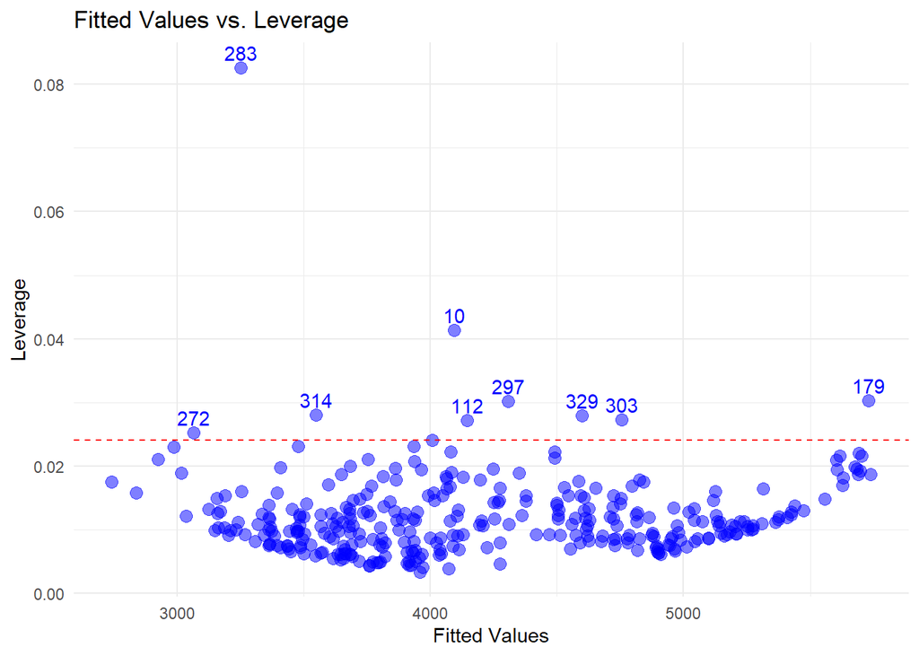

```r
library(ggplot2)
# Fit the multiple linear regression model
model <- lm(y ~ x1 + x2 + x3)

# Compute leverage scores
leverage_scores <- hatvalues(model)

# Identify influential points (optional)
influential_points <- which(leverage_scores > 2 * mean(leverage_scores))

# Create a ggplot scatter plot
ggplot(data = data.frame(Fitted = fitted(model), Leverage = leverage_scores)) +
  geom_point(aes(x = Fitted, y = Leverage), color = "blue", shape=19, alpha=0.5, size=3) +
  labs(title = "Fitted Values vs. Leverage",
       x = "Fitted Values", y = "Leverage") +
  geom_hline(yintercept = 2 * mean(leverage_scores), linetype = "dashed", color = "red") +
  geom_text(data = data.frame(Fitted = fitted(model)[influential_points],
                              Leverage = leverage_scores[influential_points],
                              Labels = influential_points),
            aes(x = Fitted, y = Leverage, label = Labels),
            color = "blue", vjust = -0.5) +
  theme_minimal()
```

To compute the leverage score for observations in a multiple linear regression model and determine which data point is more influential, you can use the `hatvalues()` function in R.

```r
# Fit the multiple linear regression model
model <- lm(y ~ x1 + x2 + x3)

# Compute leverage scores
leverage_scores <- hatvalues(model)

# Display the leverage scores for the first and second observations
leverage_first_observation <- leverage_scores[1]
leverage_second_observation <- leverage_scores[2]

cat("Leverage Score for the First Observation:", leverage_first_observation, "\n")
```

```
## Leverage Score for the First Observation: 0.009136068
```

```r
cat("Leverage Score for the Second Observation:", leverage_second_observation, "\n")
```

```
## Leverage Score for the Second Observation: 0.007558264
```

# (5) Given a new data point $x = (40, 18, 195)$, find the predicted y value and its 95% confidence interval.

```r
# New data point
new_data <- data.frame(x1 = 40, x2 = 18, x3 = 195)

# Predict the y value for the new data point
predicted_y <- predict(model, newdata = new_data, interval = "confidence")

# Print the predicted y value and its 95% confidence interval
cat("Predicted y Value:", predicted_y[1], "\n")
```

```
## Predicted y Value: 3905.909
```

```r
cat("95% Confidence Interval:", predicted_y[2], "to", predicted_y[3], "\n")
```

```
## 95% Confidence Interval: 3851.017 to 3960.801
```